# Risk Factor Analysis

## Outcome Variable

**Outcome Variable:** ever_swasted

## Predictor Variables

**Intervention Variable:** month

**Adjustment Set:**

unadjusted

## Stratifying Variables

The analysis was stratified on these variable(s):

- agecat
- studyid
- country

## Data Summary

| agecat | studyid | country | month | ever_swasted | n_cell | n |
| --- | --- | --- | --- | --- | --- | --- |
| 0-24 months (no birth wast) | CMC-V-BCS-2002 | INDIA | 1 | 0 | 25 | 368 |
| 0-24 months (no birth wast) | CMC-V-BCS-2002 | INDIA | 1 | 1 | 3 | 368 |
| 0-24 months (no birth wast) | CMC-V-BCS-2002 | INDIA | 2 | 0 | 20 | 368 |
| 0-24 months (no birth wast) | CMC-V-BCS-2002 | INDIA | 2 | 1 | 3 | 368 |
| 0-24 months (no birth wast) | CMC-V-BCS-2002 | INDIA | 3 | 0 | 21 | 368 |
| 0-24 months (no birth wast) | CMC-V-BCS-2002 | INDIA | 3 | 1 | 3 | 368 |
| 0-24 months (no birth wast) | CMC-V-BCS-2002 | INDIA | 4 | 0 | 25 | 368 |
| 0-24 months (no birth wast) | CMC-V-BCS-2002 | INDIA | 4 | 1 | 4 | 368 |
| 0-24 months (no birth wast) | CMC-V-BCS-2002 | INDIA | 5 | 0 | 36 | 368 |
| 0-24 months (no birth wast) | CMC-V-BCS-2002 | INDIA | 5 | 1 | 7 | 368 |
| 0-24 months (no birth wast) | CMC-V-BCS-2002 | INDIA | 6 | 0 | 32 | 368 |
| 0-24 months (no birth wast) | CMC-V-BCS-2002 | INDIA | 6 | 1 | 3 | 368 |
| 0-24 months (no birth wast) | CMC-V-BCS-2002 | INDIA | 7 | 0 | 29 | 368 |
| 0-24 months (no birth wast) | CMC-V-BCS-2002 | INDIA | 7 | 1 | 4 | 368 |
| 0-24 months (no birth wast) | CMC-V-BCS-2002 | INDIA | 8 | 0 | 33 | 368 |
| 0-24 months (no birth wast) | CMC-V-BCS-2002 | INDIA | 8 | 1 | 8 | 368 |
| 0-24 months (no birth wast) | CMC-V-BCS-2002 | INDIA | 9 | 0 | 17 | 368 |
| 0-24 months (no birth wast) | CMC-V-BCS-2002 | INDIA | 9 | 1 | 6 | 368 |
| 0-24 months (no birth wast) | CMC-V-BCS-2002 | INDIA | 10 | 0 | 15 | 368 |
| 0-24 months (no birth wast) | CMC-V-BCS-2002 | INDIA | 10 | 1 | 4 | 368 |
| 0-24 months (no birth wast) | CMC-V-BCS-2002 | INDIA | 11 | 0 | 35 | 368 |
| 0-24 months (no birth wast) | CMC-V-BCS-2002 | INDIA | 11 | 1 | 6 | 368 |
| 0-24 months (no birth wast) | CMC-V-BCS-2002 | INDIA | 12 | 0 | 25 | 368 |
| 0-24 months (no birth wast) | CMC-V-BCS-2002 | INDIA | 12 | 1 | 4 | 368 |
| 0-24 months (no birth wast) | CMIN | BANGLADESH | 1 | 0 | 21 | 268 |
| 0-24 months (no birth wast) | CMIN | BANGLADESH | 1 | 1 | 7 | 268 |
| 0-24 months (no birth wast) | CMIN | BANGLADESH | 2 | 0 | 28 | 268 |
| 0-24 months (no birth wast) | CMIN | BANGLADESH | 2 | 1 | 6 | 268 |
| 0-24 months (no birth wast) | CMIN | BANGLADESH | 3 | 0 | 19 | 268 |
| 0-24 months (no birth wast) | CMIN | BANGLADESH | 3 | 1 | 1 | 268 |

[output cut: 1674 more lines]

The following strata were considered:

- agecat: 0-24 months (no birth wast), studyid: CMC-V-BCS-2002, country: INDIA
- agecat: 0-24 months (no birth wast), studyid: CMIN, country: BANGLADESH
- agecat: 0-24 months (no birth wast), studyid: CONTENT, country: PERU
- agecat: 0-24 months (no birth wast), studyid: EE, country: PAKISTAN
- agecat: 0-24 months (no birth wast), studyid: GMS-Nepal, country: NEPAL
- agecat: 0-24 months (no birth wast), studyid: Guatemala BSC, country: GUATEMALA
- agecat: 0-24 months (no birth wast), studyid: iLiNS-Zinc, country: BURKINA FASO
- agecat: 0-24 months (no birth wast), studyid: IRC, country: INDIA
- agecat: 0-24 months (no birth wast), studyid: Keneba, country: GAMBIA
- agecat: 0-24 months (no birth wast), studyid: LCNI-5, country: MALAWI
- agecat: 0-24 months (no birth wast), studyid: MAL-ED, country: BANGLADESH
- agecat: 0-24 months (no birth wast), studyid: MAL-ED, country: BRAZIL
- agecat: 0-24 months (no birth wast), studyid: MAL-ED, country: INDIA
- agecat: 0-24 months (no birth wast), studyid: MAL-ED, country: NEPAL
- agecat: 0-24 months (no birth wast), studyid: MAL-ED, country: PERU
- agecat: 0-24 months (no birth wast), studyid: MAL-ED, country: SOUTH AFRICA
- agecat: 0-24 months (no birth wast), studyid: MAL-ED, country: TANZANIA, UNITED REPUBLIC OF
- agecat: 0-24 months (no birth wast), studyid: NIH-Birth, country: BANGLADESH
- agecat: 0-24 months (no birth wast), studyid: PROBIT, country: BELARUS
- agecat: 0-24 months (no birth wast), studyid: ResPak, country: PAKISTAN
- agecat: 0-24 months (no birth wast), studyid: SAS-CompFeed, country: INDIA
- agecat: 0-24 months (no birth wast), studyid: SAS-FoodSuppl, country: INDIA
- agecat: 0-24 months (no birth wast), studyid: TanzaniaChild2, country: TANZANIA, UNITED REPUBLIC OF
- agecat: 0-24 months (no birth wast), studyid: ZVITAMBO, country: ZIMBABWE
- agecat: 0-6 months (no birth wast), studyid: CMC-V-BCS-2002, country: INDIA
- agecat: 0-6 months (no birth wast), studyid: CMIN, country: BANGLADESH
- agecat: 0-6 months (no birth wast), studyid: CONTENT, country: PERU
- agecat: 0-6 months (no birth wast), studyid: EE, country: PAKISTAN
- agecat: 0-6 months (no birth wast), studyid: GMS-Nepal, country: NEPAL
- agecat: 0-6 months (no birth wast), studyid: Guatemala BSC, country: GUATEMALA
- agecat: 0-6 months (no birth wast), studyid: IRC, country: INDIA
- agecat: 0-6 months (no birth wast), studyid: Keneba, country: GAMBIA
- agecat: 0-6 months (no birth wast), studyid: LCNI-5, country: MALAWI
- agecat: 0-6 months (no birth wast), studyid: MAL-ED, country: BANGLADESH
- agecat: 0-6 months (no birth wast), studyid: MAL-ED, country: BRAZIL
- agecat: 0-6 months (no birth wast), studyid: MAL-ED, country: INDIA
- agecat: 0-6 months (no birth wast), studyid: MAL-ED, country: NEPAL
- agecat: 0-6 months (no birth wast), studyid: MAL-ED, country: PERU
- agecat: 0-6 months (no birth wast), studyid: MAL-ED, country: SOUTH AFRICA
- agecat: 0-6 months (no birth wast), studyid: MAL-ED, country: TANZANIA, UNITED REPUBLIC OF
- agecat: 0-6 months (no birth wast), studyid: NIH-Birth, country: BANGLADESH
- agecat: 0-6 months (no birth wast), studyid: PROBIT, country: BELARUS
- agecat: 0-6 months (no birth wast), studyid: ResPak, country: PAKISTAN
- agecat: 0-6 months (no birth wast), studyid: SAS-CompFeed, country: INDIA
- agecat: 0-6 months (no birth wast), studyid: SAS-FoodSuppl, country: INDIA
- agecat: 0-6 months (no birth wast), studyid: TanzaniaChild2, country: TANZANIA, UNITED REPUBLIC OF
- agecat: 0-6 months (no birth wast), studyid: ZVITAMBO, country: ZIMBABWE
- agecat: 6-24 months, studyid: CMC-V-BCS-2002, country: INDIA
- agecat: 6-24 months, studyid: CMIN, country: BANGLADESH
- agecat: 6-24 months, studyid: CONTENT, country: PERU
- agecat: 6-24 months, studyid: EE, country: PAKISTAN
- agecat: 6-24 months, studyid: GMS-Nepal, country: NEPAL
- agecat: 6-24 months, studyid: Guatemala BSC, country: GUATEMALA
- agecat: 6-24 months, studyid: iLiNS-Zinc, country: BURKINA FASO
- agecat: 6-24 months, studyid: IRC, country: INDIA
- agecat: 6-24 months, studyid: Keneba, country: GAMBIA
- agecat: 6-24 months, studyid: LCNI-5, country: MALAWI
- agecat: 6-24 months, studyid: MAL-ED, country: BANGLADESH
- agecat: 6-24 months, studyid: MAL-ED, country: BRAZIL
- agecat: 6-24 months, studyid: MAL-ED, country: INDIA
- agecat: 6-24 months, studyid: MAL-ED, country: NEPAL
- agecat: 6-24 months, studyid: MAL-ED, country: PERU
- agecat: 6-24 months, studyid: MAL-ED, country: SOUTH AFRICA
- agecat: 6-24 months, studyid: MAL-ED, country: TANZANIA, UNITED REPUBLIC OF
- agecat: 6-24 months, studyid: NIH-Birth, country: BANGLADESH
- agecat: 6-24 months, studyid: PROBIT, country: BELARUS
- agecat: 6-24 months, studyid: ResPak, country: PAKISTAN
- agecat: 6-24 months, studyid: SAS-CompFeed, country: INDIA
- agecat: 6-24 months, studyid: SAS-FoodSuppl, country: INDIA
- agecat: 6-24 months, studyid: TanzaniaChild2, country: TANZANIA, UNITED REPUBLIC OF
- agecat: 6-24 months, studyid: ZVITAMBO, country: ZIMBABWE

### Dropped Strata

Some strata were dropped due to rare outcomes:

- agecat: 0-24 months (no birth wast), studyid: CMC-V-BCS-2002, country: INDIA
- agecat: 0-24 months (no birth wast), studyid: CMIN, country: BANGLADESH
- agecat: 0-24 months (no birth wast), studyid: CONTENT, country: PERU
- agecat: 0-24 months (no birth wast), studyid: EE, country: PAKISTAN
- agecat: 0-24 months (no birth wast), studyid: GMS-Nepal, country: NEPAL
- agecat: 0-24 months (no birth wast), studyid: Guatemala BSC, country: GUATEMALA
- agecat: 0-24 months (no birth wast), studyid: iLiNS-Zinc, country: BURKINA FASO
- agecat: 0-24 months (no birth wast), studyid: IRC, country: INDIA
- agecat: 0-24 months (no birth wast), studyid: LCNI-5, country: MALAWI
- agecat: 0-24 months (no birth wast), studyid: MAL-ED, country: BANGLADESH
- agecat: 0-24 months (no birth wast), studyid: MAL-ED, country: BRAZIL
- agecat: 0-24 months (no birth wast), studyid: MAL-ED, country: INDIA
- agecat: 0-24 months (no birth wast), studyid: MAL-ED, country: NEPAL
- agecat: 0-24 months (no birth wast), studyid: MAL-ED, country: PERU
- agecat: 0-24 months (no birth wast), studyid: MAL-ED, country: SOUTH AFRICA
- agecat: 0-24 months (no birth wast), studyid: MAL-ED, country: TANZANIA, UNITED REPUBLIC OF
- agecat: 0-24 months (no birth wast), studyid: NIH-Birth, country: BANGLADESH
- agecat: 0-24 months (no birth wast), studyid: ResPak, country: PAKISTAN
- agecat: 0-24 months (no birth wast), studyid: SAS-FoodSuppl, country: INDIA
- agecat: 0-6 months (no birth wast), studyid: CMC-V-BCS-2002, country: INDIA
- agecat: 0-6 months (no birth wast), studyid: CMIN, country: BANGLADESH
- agecat: 0-6 months (no birth wast), studyid: CONTENT, country: PERU
- agecat: 0-6 months (no birth wast), studyid: EE, country: PAKISTAN
- agecat: 0-6 months (no birth wast), studyid: GMS-Nepal, country: NEPAL
- agecat: 0-6 months (no birth wast), studyid: Guatemala BSC, country: GUATEMALA
- agecat: 0-6 months (no birth wast), studyid: IRC, country: INDIA
- agecat: 0-6 months (no birth wast), studyid: LCNI-5, country: MALAWI
- agecat: 0-6 months (no birth wast), studyid: MAL-ED, country: BANGLADESH
- agecat: 0-6 months (no birth wast), studyid: MAL-ED, country: BRAZIL
- agecat: 0-6 months (no birth wast), studyid: MAL-ED, country: INDIA
- agecat: 0-6 months (no birth wast), studyid: MAL-ED, country: NEPAL
- agecat: 0-6 months (no birth wast), studyid: MAL-ED, country: PERU
- agecat: 0-6 months (no birth wast), studyid: MAL-ED, country: SOUTH AFRICA
- agecat: 0-6 months (no birth wast), studyid: MAL-ED, country: TANZANIA, UNITED REPUBLIC OF
- agecat: 0-6 months (no birth wast), studyid: NIH-Birth, country: BANGLADESH
- agecat: 0-6 months (no birth wast), studyid: ResPak, country: PAKISTAN
- agecat: 0-6 months (no birth wast), studyid: SAS-CompFeed, country: INDIA
- agecat: 0-6 months (no birth wast), studyid: SAS-FoodSuppl, country: INDIA
- agecat: 0-6 months (no birth wast), studyid: TanzaniaChild2, country: TANZANIA, UNITED REPUBLIC OF
- agecat: 0-6 months (no birth wast), studyid: ZVITAMBO, country: ZIMBABWE
- agecat: 6-24 months, studyid: CMC-V-BCS-2002, country: INDIA
- agecat: 6-24 months, studyid: CMIN, country: BANGLADESH
- agecat: 6-24 months, studyid: CONTENT, country: PERU
- agecat: 6-24 months, studyid: EE, country: PAKISTAN
- agecat: 6-24 months, studyid: GMS-Nepal, country: NEPAL
- agecat: 6-24 months, studyid: Guatemala BSC, country: GUATEMALA
- agecat: 6-24 months, studyid: IRC, country: INDIA
- agecat: 6-24 months, studyid: LCNI-5, country: MALAWI
- agecat: 6-24 months, studyid: MAL-ED, country: BANGLADESH
- agecat: 6-24 months, studyid: MAL-ED, country: BRAZIL
- agecat: 6-24 months, studyid: MAL-ED, country: INDIA
- agecat: 6-24 months, studyid: MAL-ED, country: NEPAL
- agecat: 6-24 months, studyid: MAL-ED, country: PERU
- agecat: 6-24 months, studyid: MAL-ED, country: SOUTH AFRICA
- agecat: 6-24 months, studyid: MAL-ED, country: TANZANIA, UNITED REPUBLIC OF
- agecat: 6-24 months, studyid: NIH-Birth, country: BANGLADESH
- agecat: 6-24 months, studyid: PROBIT, country: BELARUS
- agecat: 6-24 months, studyid: ResPak, country: PAKISTAN
- agecat: 6-24 months, studyid: SAS-CompFeed, country: INDIA
- agecat: 6-24 months, studyid: SAS-FoodSuppl, country: INDIA
- agecat: 6-24 months, studyid: TanzaniaChild2, country: TANZANIA, UNITED REPUBLIC OF

## Methods Detail

We’re interested in the causal parameters $E[Y_a]$ for all values of $a \in \mathcal{A}$. These parameters represent the mean outcome if, possibly contrary to fact, we intervened to set all units to have $A=a$. Under the randomization and positivity assumptions, these are identified by the statistical parameters $\psi_a=E_W[E_{Y|A,W}(Y|A=a,W)]$. In addition, we’re interested in the mean of $Y$, $E[Y]$ under no intervention (the observed mean). We will estimate these parameters by using SuperLearner to fit the relevant likelihood factors – $E_{Y|A,W}(Y|A=a,W)$ and $p(A=a|W)$, and then updating our likelihood fit using a joint TMLE.

For unadjusted analyses ($W=\{\}$), initial likelihoods were estimated using Lrnr_glm to estimate the simple $E(Y|A)$ and Lrnr_mean to estimate $p(A)$. For adjusted analyses, a small library containing Lrnr_glmnet, Lrnr_xgboost, and Lrnr_mean was used.

Having estimated these parameters, we will then use the delta method to estimate relative risks and attributable risks relative to a prespecified baseline level of $A$.

# Results Detail

## Results Plots

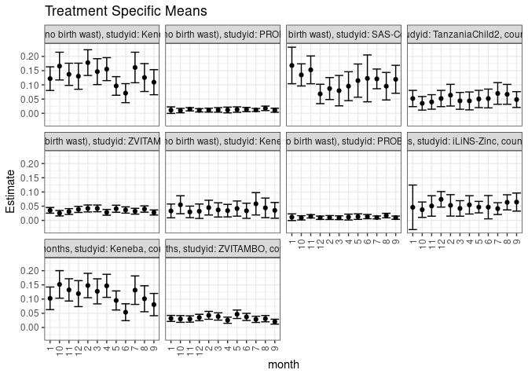

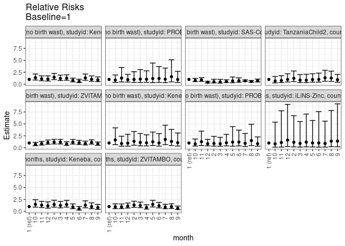

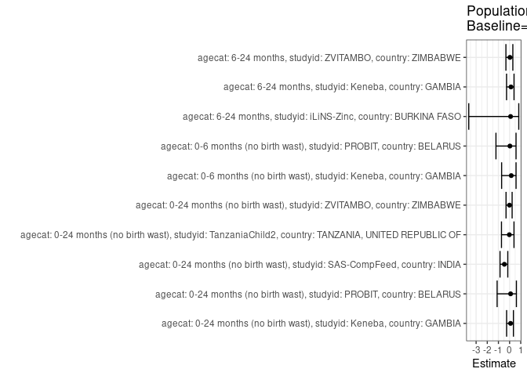

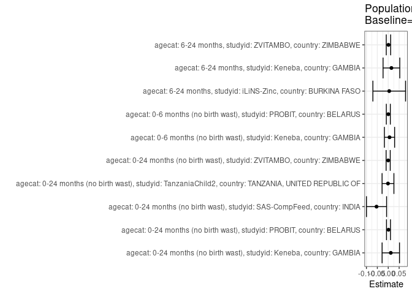

## Results Table

### Parameter: TSM

| agecat | studyid | country | intervention_level | baseline_level | estimate | ci_lower | ci_upper |
| --- | --- | --- | --- | --- | --- | --- | --- |
| 0-24 months (no birth wast) | Keneba | GAMBIA | 1 | NA | 0.1218487 | 0.0802835 | 0.1634140 |
| 0-24 months (no birth wast) | Keneba | GAMBIA | 2 | NA | 0.1781818 | 0.1329466 | 0.2234171 |
| 0-24 months (no birth wast) | Keneba | GAMBIA | 3 | NA | 0.1465517 | 0.1010357 | 0.1920677 |
| 0-24 months (no birth wast) | Keneba | GAMBIA | 4 | NA | 0.1553398 | 0.1149449 | 0.1957347 |
| 0-24 months (no birth wast) | Keneba | GAMBIA | 5 | NA | 0.0961538 | 0.0634366 | 0.1288711 |
| 0-24 months (no birth wast) | Keneba | GAMBIA | 6 | NA | 0.0707965 | 0.0373515 | 0.1042414 |
| 0-24 months (no birth wast) | Keneba | GAMBIA | 7 | NA | 0.1611111 | 0.1073953 | 0.2148270 |
| 0-24 months (no birth wast) | Keneba | GAMBIA | 8 | NA | 0.1257143 | 0.0765869 | 0.1748417 |
| 0-24 months (no birth wast) | Keneba | GAMBIA | 9 | NA | 0.1093750 | 0.0652200 | 0.1535300 |
| 0-24 months (no birth wast) | Keneba | GAMBIA | 10 | NA | 0.1659193 | 0.1170851 | 0.2147535 |
| 0-24 months (no birth wast) | Keneba | GAMBIA | 11 | NA | 0.1371237 | 0.0981279 | 0.1761196 |
| 0-24 months (no birth wast) | Keneba | GAMBIA | 12 | NA | 0.1304348 | 0.0845481 | 0.1763214 |
| 0-24 months (no birth wast) | PROBIT | BELARUS | 1 | NA | 0.0109890 | -0.0005213 | 0.0224994 |
| 0-24 months (no birth wast) | PROBIT | BELARUS | 2 | NA | 0.0109562 | 0.0041463 | 0.0177661 |
| 0-24 months (no birth wast) | PROBIT | BELARUS | 3 | NA | 0.0118143 | 0.0038429 | 0.0197858 |
| 0-24 months (no birth wast) | PROBIT | BELARUS | 4 | NA | 0.0115146 | 0.0014326 | 0.0215966 |
| 0-24 months (no birth wast) | PROBIT | BELARUS | 5 | NA | 0.0130435 | 0.0035236 | 0.0225634 |
| 0-24 months (no birth wast) | PROBIT | BELARUS | 6 | NA | 0.0131148 | 0.0057503 | 0.0204792 |
| 0-24 months (no birth wast) | PROBIT | BELARUS | 7 | NA | 0.0115332 | 0.0062193 | 0.0168472 |
| 0-24 months (no birth wast) | PROBIT | BELARUS | 8 | NA | 0.0173375 | 0.0095079 | 0.0251671 |
| 0-24 months (no birth wast) | PROBIT | BELARUS | 9 | NA | 0.0106986 | 0.0036671 | 0.0177300 |
| 0-24 months (no birth wast) | PROBIT | BELARUS | 10 | NA | 0.0094340 | 0.0016492 | 0.0172187 |
| 0-24 months (no birth wast) | PROBIT | BELARUS | 11 | NA | 0.0140845 | 0.0082830 | 0.0198861 |
| 0-24 months (no birth wast) | PROBIT | BELARUS | 12 | NA | 0.0104167 | 0.0045171 | 0.0163163 |
| 0-24 months (no birth wast) | SAS-CompFeed | INDIA | 1 | NA | 0.1682243 | 0.1039350 | 0.2325136 |
| 0-24 months (no birth wast) | SAS-CompFeed | INDIA | 2 | NA | 0.0869565 | 0.0483028 | 0.1256102 |
| 0-24 months (no birth wast) | SAS-CompFeed | INDIA | 3 | NA | 0.0795455 | 0.0261268 | 0.1329641 |
| 0-24 months (no birth wast) | SAS-CompFeed | INDIA | 4 | NA | 0.0952381 | 0.0443913 | 0.1460849 |
| 0-24 months (no birth wast) | SAS-CompFeed | INDIA | 5 | NA | 0.1149425 | 0.0564882 | 0.1733969 |
| 0-24 months (no birth wast) | SAS-CompFeed | INDIA | 6 | NA | 0.1228070 | 0.0403659 | 0.2052481 |

[output cut: 90 more lines]

### Parameter: E(Y)

| agecat | studyid | country | intervention_level | baseline_level | estimate | ci_lower | ci_upper |
| --- | --- | --- | --- | --- | --- | --- | --- |
| 0-24 months (no birth wast) | Keneba | GAMBIA | NA | NA | 0.1335425 | 0.1210912 | 0.1459939 |
| 0-24 months (no birth wast) | PROBIT | BELARUS | NA | NA | 0.0120860 | 0.0083142 | 0.0158578 |
| 0-24 months (no birth wast) | SAS-CompFeed | INDIA | NA | NA | 0.1145140 | 0.0913579 | 0.1376700 |
| 0-24 months (no birth wast) | TanzaniaChild2 | TANZANIA, UNITED REPUBLIC OF | NA | NA | 0.0507550 | 0.0419422 | 0.0595679 |
| 0-24 months (no birth wast) | ZVITAMBO | ZIMBABWE | NA | NA | 0.0350517 | 0.0319649 | 0.0381385 |
| 0-6 months (no birth wast) | Keneba | GAMBIA | NA | NA | 0.0391914 | 0.0314649 | 0.0469180 |
| 0-6 months (no birth wast) | PROBIT | BELARUS | NA | NA | 0.0115018 | 0.0077384 | 0.0152653 |
| 6-24 months | iLiNS-Zinc | BURKINA FASO | NA | NA | 0.0505205 | 0.0383088 | 0.0627322 |
| 6-24 months | Keneba | GAMBIA | NA | NA | 0.1172389 | 0.1051866 | 0.1292911 |
| 6-24 months | ZVITAMBO | ZIMBABWE | NA | NA | 0.0329172 | 0.0295545 | 0.0362800 |

### Parameter: RR

| agecat | studyid | country | intervention_level | baseline_level | estimate | ci_lower | ci_upper |
| --- | --- | --- | --- | --- | --- | --- | --- |
| 0-24 months (no birth wast) | Keneba | GAMBIA | 1 | 1 | 1.0000000 | 1.0000000 | 1.0000000 |
| 0-24 months (no birth wast) | Keneba | GAMBIA | 2 | 1 | 1.4623197 | 0.9558071 | 2.2372495 |
| 0-24 months (no birth wast) | Keneba | GAMBIA | 3 | 1 | 1.2027348 | 0.7582590 | 1.9077533 |
| 0-24 months (no birth wast) | Keneba | GAMBIA | 4 | 1 | 1.2748577 | 0.8301893 | 1.9577007 |
| 0-24 months (no birth wast) | Keneba | GAMBIA | 5 | 1 | 0.7891247 | 0.4874143 | 1.2775943 |
| 0-24 months (no birth wast) | Keneba | GAMBIA | 6 | 1 | 0.5810192 | 0.3244356 | 1.0405249 |
| 0-24 months (no birth wast) | Keneba | GAMBIA | 7 | 1 | 1.3222222 | 0.8206303 | 2.1304009 |
| 0-24 months (no birth wast) | Keneba | GAMBIA | 8 | 1 | 1.0317241 | 0.6141624 | 1.7331811 |
| 0-24 months (no birth wast) | Keneba | GAMBIA | 9 | 1 | 0.8976293 | 0.5291283 | 1.5227655 |
| 0-24 months (no birth wast) | Keneba | GAMBIA | 10 | 1 | 1.3616824 | 0.8677735 | 2.1367083 |
| 0-24 months (no birth wast) | Keneba | GAMBIA | 11 | 1 | 1.1253604 | 0.7217963 | 1.7545615 |
| 0-24 months (no birth wast) | Keneba | GAMBIA | 12 | 1 | 1.0704648 | 0.6557778 | 1.7473829 |
| 0-24 months (no birth wast) | PROBIT | BELARUS | 1 | 1 | 1.0000000 | 1.0000000 | 1.0000000 |
| 0-24 months (no birth wast) | PROBIT | BELARUS | 2 | 1 | 0.9970120 | 0.3792292 | 2.6211931 |
| 0-24 months (no birth wast) | PROBIT | BELARUS | 3 | 1 | 1.0751055 | 0.3765928 | 3.0692349 |
| 0-24 months (no birth wast) | PROBIT | BELARUS | 4 | 1 | 1.0478299 | 0.3913077 | 2.8058418 |
| 0-24 months (no birth wast) | PROBIT | BELARUS | 5 | 1 | 1.1869565 | 0.3183043 | 4.4261602 |
| 0-24 months (no birth wast) | PROBIT | BELARUS | 6 | 1 | 1.1934426 | 0.3845937 | 3.7034024 |
| 0-24 months (no birth wast) | PROBIT | BELARUS | 7 | 1 | 1.0495251 | 0.3253506 | 3.3855877 |
| 0-24 months (no birth wast) | PROBIT | BELARUS | 8 | 1 | 1.5777090 | 0.4867609 | 5.1137335 |
| 0-24 months (no birth wast) | PROBIT | BELARUS | 9 | 1 | 0.9735683 | 0.3511141 | 2.6995080 |
| 0-24 months (no birth wast) | PROBIT | BELARUS | 10 | 1 | 0.8584906 | 0.3818334 | 1.9301769 |
| 0-24 months (no birth wast) | PROBIT | BELARUS | 11 | 1 | 1.2816901 | 0.4683780 | 3.5072736 |
| 0-24 months (no birth wast) | PROBIT | BELARUS | 12 | 1 | 0.9479167 | 0.4359708 | 2.0610235 |
| 0-24 months (no birth wast) | SAS-CompFeed | INDIA | 1 | 1 | 1.0000000 | 1.0000000 | 1.0000000 |
| 0-24 months (no birth wast) | SAS-CompFeed | INDIA | 2 | 1 | 0.5169082 | 0.2569695 | 1.0397892 |
| 0-24 months (no birth wast) | SAS-CompFeed | INDIA | 3 | 1 | 0.4728535 | 0.2210127 | 1.0116632 |
| 0-24 months (no birth wast) | SAS-CompFeed | INDIA | 4 | 1 | 0.5661376 | 0.3448096 | 0.9295325 |
| 0-24 months (no birth wast) | SAS-CompFeed | INDIA | 5 | 1 | 0.6832695 | 0.3107527 | 1.5023429 |
| 0-24 months (no birth wast) | SAS-CompFeed | INDIA | 6 | 1 | 0.7300195 | 0.4017844 | 1.3264042 |

[output cut: 90 more lines]

### Parameter: PAR

| agecat | studyid | country | intervention_level | baseline_level | estimate | ci_lower | ci_upper |
| --- | --- | --- | --- | --- | --- | --- | --- |
| 0-24 months (no birth wast) | Keneba | GAMBIA | 1 | NA | 0.0116938 | -0.0282558 | 0.0516434 |
| 0-24 months (no birth wast) | PROBIT | BELARUS | 1 | NA | 0.0010970 | -0.0080146 | 0.0102086 |
| 0-24 months (no birth wast) | SAS-CompFeed | INDIA | 1 | NA | -0.0537103 | -0.0998388 | -0.0075819 |
| 0-24 months (no birth wast) | TanzaniaChild2 | TANZANIA, UNITED REPUBLIC OF | 1 | NA | -0.0011930 | -0.0283634 | 0.0259774 |
| 0-24 months (no birth wast) | ZVITAMBO | ZIMBABWE | 1 | NA | -0.0003399 | -0.0097767 | 0.0090969 |
| 0-6 months (no birth wast) | Keneba | GAMBIA | 1 | NA | 0.0058581 | -0.0175343 | 0.0292504 |
| 0-6 months (no birth wast) | PROBIT | BELARUS | 1 | NA | 0.0003526 | -0.0088315 | 0.0095367 |
| 6-24 months | iLiNS-Zinc | BURKINA FASO | 1 | NA | 0.0044954 | -0.0703896 | 0.0793804 |
| 6-24 months | Keneba | GAMBIA | 1 | NA | 0.0145603 | -0.0237447 | 0.0528653 |
| 6-24 months | ZVITAMBO | ZIMBABWE | 1 | NA | 0.0009624 | -0.0090887 | 0.0110135 |

### Parameter: PAF

| agecat | studyid | country | intervention_level | baseline_level | estimate | ci_lower | ci_upper |
| --- | --- | --- | --- | --- | --- | --- | --- |
| 0-24 months (no birth wast) | Keneba | GAMBIA | 1 | NA | 0.0875661 | -0.2663447 | 0.3425679 |
| 0-24 months (no birth wast) | PROBIT | BELARUS | 1 | NA | 0.0907671 | -1.1178451 | 0.6096483 |
| 0-24 months (no birth wast) | SAS-CompFeed | INDIA | 1 | NA | -0.4690285 | -0.8573368 | -0.1619027 |
| 0-24 months (no birth wast) | TanzaniaChild2 | TANZANIA, UNITED REPUBLIC OF | 1 | NA | -0.0235054 | -0.7267651 | 0.3933377 |
| 0-24 months (no birth wast) | ZVITAMBO | ZIMBABWE | 1 | NA | -0.0096962 | -0.3182281 | 0.2266236 |
| 0-6 months (no birth wast) | Keneba | GAMBIA | 1 | NA | 0.1494737 | -0.7144186 | 0.5780523 |
| 0-6 months (no birth wast) | PROBIT | BELARUS | 1 | NA | 0.0306559 | -1.2221113 | 0.5771463 |
| 6-24 months | iLiNS-Zinc | BURKINA FASO | 1 | NA | 0.0889819 | -3.6594758 | 0.8218782 |
| 6-24 months | Keneba | GAMBIA | 1 | NA | 0.1241934 | -0.2715400 | 0.3967651 |
| 6-24 months | ZVITAMBO | ZIMBABWE | 1 | NA | 0.0292357 | -0.3295686 | 0.2912111 |